# Project #1 Revisions - Alec Tandoc

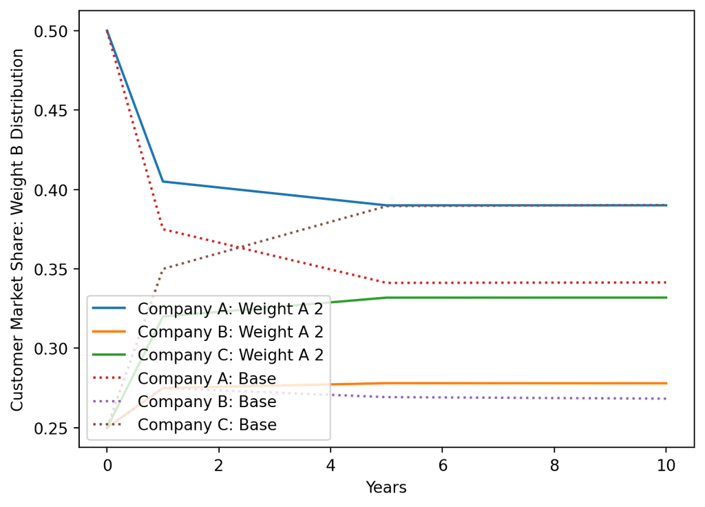

```python
market = plan2_states[1]
for i in range(3):
  plt.plot(time, [market[0][i], market[1][i], market[2][i], market[3][i]], label=f"Company {companies[i]}: Weight A 2")
market = base_states[1]
for i in range(3):
  plt.plot(time, [market[0][i], market[1][i], market[2][i], market[3][i]], label=f"Company {companies[i]}: Base", linestyle=":")
plt.ylabel('Customer Market Share: Weight B Distribution')
plt.xlabel('Years')
plt.legend(loc=3)
plt.show()
```

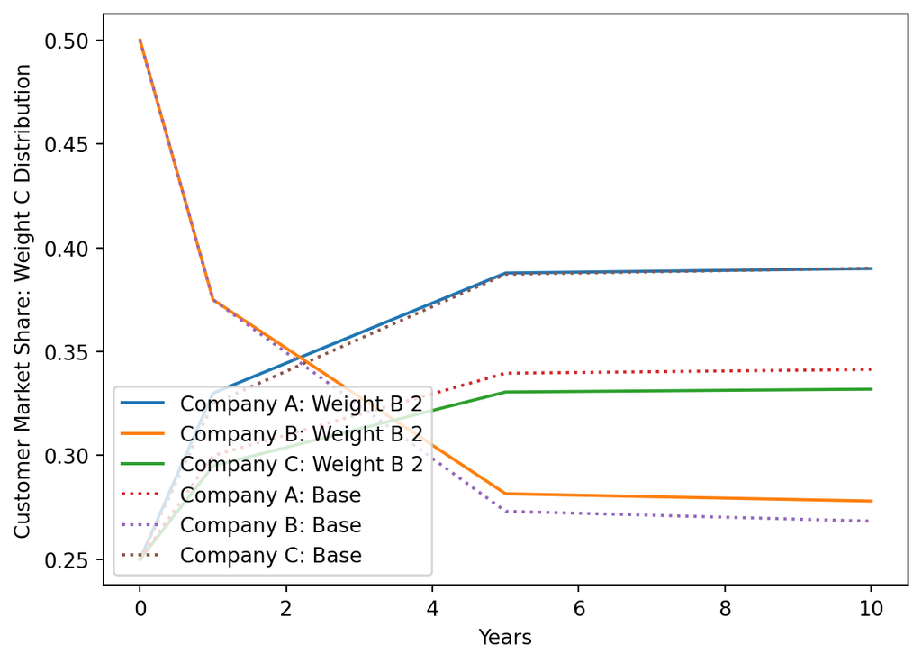

```python
market = plan2_states[2]
for i in range(3):
  plt.plot(time, [market[0][i], market[1][i], market[2][i], market[3][i]], label=f"Company {companies[i]}: Weight B 2")
market = base_states[2]
for i in range(3):
  plt.plot(time, [market[0][i], market[1][i], market[2][i], market[3][i]], label=f"Company {companies[i]}: Base", linestyle=":")
plt.ylabel('Customer Market Share: Weight C Distribution')
plt.xlabel('Years')
plt.legend(loc=3)
plt.show()
```

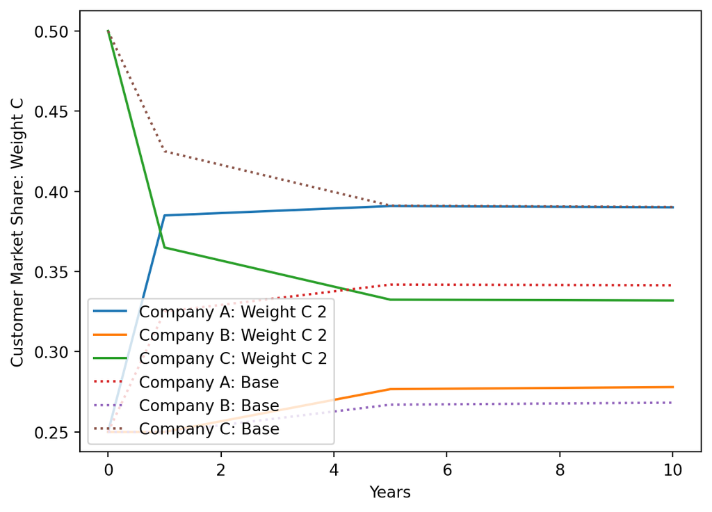

```python
market = plan2_states[3]
for i in range(3):
  plt.plot(time, [market[0][i], market[1][i], market[2][i], market[3][i]], label=f"Company {companies[i]}: Weight C 2")
market = base_states[3]
for i in range(3):
  plt.plot(time, [market[0][i], market[1][i], market[2][i], market[3][i]], label=f"Company {companies[i]}: Base", linestyle=":")
plt.ylabel('Customer Market Share: Weight C')
plt.xlabel('Years')
plt.legend(loc=3)
plt.show()
```

As demonstrated, A performs consistently better under Plan 2 than the original plan. Thus, we can see that it would be ideal for the company to undergo marketing strategies to implement plan 2. For exceptional circumstances, we consider a market in which we start with 0% of the user base. However, as displayed below, even if we start with 0 market share, our new marketing strategy will propel us to the largest market holder within a 10 year period.

```python
(plan2 ** 10) * sp.Matrix([0.0, 0.99, .01])
```

$\displaystyle \left[\begin{matrix}0.389923740012833\\0.278200270113832\\0.331875989873334\end{matrix}\right]$

::: comments This is much clearer now – I can understand exactly what you are doing in each bit of code, and why. It definitely meets expectations, and is appropriate for projects in this class. Nice!